Estudiante: Baez Edgardo Anselmo - Comisión 2026 - TPI Data Analytics

```python
# Importar la librería Pandas
import pandas as pd
```

# Etapa 1: Recopilación y Preparación de Datos (Clases 1 a 4)

### 1_1- Cargar los set de datos como Dataframes

```python
def cargar_dataset(url):
  # Importamos usando el método read_csv() directamente con la url
  df = pd.read_csv(url)
  return df
```

### Opción Alternativa: Montar Google Drive

En Colab, a menudo es más sencillo montar tu unidad de Drive para acceder a los archivos como si estuvieran en una carpeta local.

```python
# Carga de drive deshabilitada para ejecución en contenedor
```

### Cargar el archivo desde la ruta de Drive

Una vez montado, puedes buscar el archivo en el panel izquierdo (icono de carpeta). Haz clic derecho sobre el archivo y selecciona 'Copiar ruta' para obtener la dirección exacta.

```python
# Cargamos el dataset de clientes desde GitHub
import pandas as pd
url_cli = "https://raw.githubusercontent.com/gitpapiweb/data/main/clientes.csv"
df_cli = pd.read_csv(url_cli)
print("✅ Archivo clientes.csv cargado exitosamente.")
display(df_cli.head())
```

```
✅ Archivo clientes.csv cargado exitosamente.
```

|  | id_cliente | nombre | edad | ciudad | ingresos |
| --- | --- | --- | --- | --- | --- |
| 0 | 1 | Aloysia Screase | 44 | Mar del Plata | 42294.68 |
| 1 | 2 | Kristina Scaplehorn | 25 | Posadas | 24735.04 |
| 2 | 3 | Filip Castagne | 50 | Resistencia | 35744.85 |
| 3 | 4 | Liuka Luard | 39 | Bahía Blanca | 27647.96 |
| 4 | 5 | Dore Cockshtt | 28 | Rosario | 28245.65 |

```python
# Cargamos el resto de los datasets desde GitHub
url_ven = "https://raw.githubusercontent.com/gitpapiweb/data/main/ventas.csv"
url_mar = "https://raw.githubusercontent.com/gitpapiweb/data/main/marketing.csv"
df_ven = pd.read_csv(url_ven)
df_mar = pd.read_csv(url_mar)
print("✅ Archivos ventas.csv y marketing.csv cargados correctamente.")
df_ven_pp = df_ven.copy()
df_mar_pp = df_mar.copy()
print(f"Ventas: {df_ven.shape[0]} filas | Marketing: {df_mar.shape[0]} filas")
```

```
✅ Archivos ventas.csv y marketing.csv cargados correctamente.
Ventas: 3035 filas | Marketing: 90 filas
```

```python
# Carga de drive deshabilitada para ejecución en contenedor
```

### Versión optimizada de `cargar_dataset`

usando links compartidos, esta versión es un poco mejor para entornos Colab:

```python
import pandas as pd
import re

def cargar_dataset_colab(link):
    # Extrae el ID de manera más segura
    match = re.search(r'[-\w]{25,}', link)
    if not match:
        return "No se encontró un ID de archivo válido"

    file_id = match.group()
    url = f'/content/drive/MyDrive/Baez Edgardo Anselmo - Comisión 2026 - TPI Data Analytics'
    return pd.read_csv(url)
```

### dataset clientes

```python
# Carga desactivada en favor de la carga inicial.
```

```python
# Carga desactivada en favor de la carga inicial.
```

### dataset ventas

```python
# Carga desactivada en favor de la carga inicial.
```

### dataset marketing

```python
# Carga de datos migrada a carga inicial en Cell 9.
```

## 1_4- Análisis exploratorio inicial de los DataFrames.

Generamos una función con los métodos que deseamos incluir en el EDA Inicial

```python
def resumen_eda(df):
    print("📊 Dimensiones del dataset")
    print(f"Filas: {df.shape[0]}")
    print(f"Columnas: {df.shape[1]}")
    print("-" * 40)

    print("\n🔎 Tipos de datos")
    print(df.dtypes)
    print("-" * 40)

    print("\n🔎 Primeros registros")
    print(df.head(2))
    print("-" * 40)

    print("\n📈 Estadísticas descriptivas")
    print(df.describe(include='number'))
    print("-" * 40)

    print("\n📈 Estadísticas descriptivas")
    try:
        print(df.describe(include=['object', 'str']))
    except:
      print("No hay variables categóricas")
    print("-" * 40)

    print("\n⚠️ Valores nulos por columna")
    nulos = df.isnull().sum()
    if (nulos > 0).any():
        print(nulos[nulos > 0].sort_values(ascending=False))
    else:
        print("No hay valores nulos en el DataFrame (0 en todas las columnas)")
    print("-" * 40)

    print("\n📌 Porcentaje de nulos por columna")
    porcentaje_nulos = df.isnull().mean() * 100
    if (porcentaje_nulos > 0).any():
        print(porcentaje_nulos[porcentaje_nulos > 0].sort_values(ascending=False))
    else:
        print("No hay valores nulos (0% en todas las columnas)")
    print("-" * 40)

    print("\n🔁 Registros duplicados")
    duplicados = df.duplicated().sum()
    print(f"Cantidad de duplicados: {duplicados}")
    print("-" * 40)
```

## 1_5- Calidad de Datos

En esta sección usamos la función definida en el item 4, aplicada a cada dataframe, y documentamos las acciones para limpiar y transformar nuestros datos

### EDA clientes

```python
# Ahora que df_cli está cargado, invocamos a la función
resumen_eda(df_cli)
```

```
📊 Dimensiones del dataset
Filas: 567
Columnas: 5
----------------------------------------

🔎 Tipos de datos
id_cliente      int64
nombre            str
edad            int64
ciudad            str
ingresos      float64
dtype: object
----------------------------------------

🔎 Primeros registros
   id_cliente               nombre  edad         ciudad  ingresos
0           1      Aloysia Screase    44  Mar del Plata  42294.68
1           2  Kristina Scaplehorn    25        Posadas  24735.04
----------------------------------------

📈 Estadísticas descriptivas
       id_cliente        edad      ingresos
count  567.000000  567.000000    567.000000
mean   284.000000   37.940035  34668.739012
std    163.823075   10.202885  12974.531446
min      1.000000   20.000000    170.290000
25%    142.500000   30.000000  26015.240000
50%    284.000000   37.000000  35066.830000
75%    425.500000   43.000000  42457.100000
max    567.000000   81.000000  88053.010000
----------------------------------------

📈 Estadísticas descriptivas
                 nombre         ciudad
count               567            567
unique              567             12
top     Aloysia Screase  Mar del Plata
freq                  1             63
----------------------------------------

⚠️ Valores nulos por columna
No hay valores nulos en el DataFrame (0 en todas las columnas)
----------------------------------------

📌 Porcentaje de nulos por columna
No hay valores nulos (0% en todas las columnas)
----------------------------------------

🔁 Registros duplicados
Cantidad de duplicados: 0
----------------------------------------
```

### Visualizaciones Complementarias de Clientes

Para profundizar en el EDA de clientes, veremos la distribución geográfica y económica.

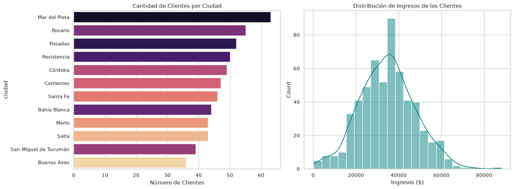

```python
import matplotlib.pyplot as plt
import seaborn as sns

# Configuración de estilo
sns.set_theme(style="whitegrid")
fig, axes = plt.subplots(1, 2, figsize=(16, 6))

# 1. Distribución de clientes por ciudad
sns.countplot(data=df_cli, y='ciudad', hue='ciudad', legend=False, order=df_cli['ciudad'].value_counts().index, ax=axes[0], palette='magma')
axes[0].set_title('Cantidad de Clientes por Ciudad')
axes[0].set_xlabel('Número de Clientes')

# 2. Distribución de ingresos
sns.histplot(df_cli['ingresos'], kde=True, ax=axes[1], color='teal')
axes[1].set_title('Distribución de Ingresos de los Clientes')
axes[1].set_xlabel('Ingresos ($)')

plt.tight_layout()
plt.show()
```

### EDA ventas

```python
resumen_eda(df_ven)
```

```
📊 Dimensiones del dataset
Filas: 3035
Columnas: 6
----------------------------------------

🔎 Tipos de datos
id_venta         int64
producto           str
precio             str
cantidad       float64
fecha_venta        str
categoria          str
dtype: object
----------------------------------------

🔎 Primeros registros
   id_venta           producto   precio  cantidad fecha_venta   categoria
0       792  Cuadro decorativo   $69.94       5.0  02/01/2024  Decoración
1       811    Lámpara de mesa  $105.10       5.0  02/01/2024  Decoración
----------------------------------------

📈 Estadísticas descriptivas
          id_venta     cantidad
count  3035.000000  3033.000000
mean   1499.851400     6.496538
std     866.465379     3.457250
min       1.000000     1.000000
25%     748.500000     3.000000
50%    1502.000000     7.000000
75%    2249.500000     9.000000
max    3000.000000    12.000000
----------------------------------------

📈 Estadísticas descriptivas
               producto  precio fecha_venta   categoria
count              3035    3033        3035        3035
unique               30    2590         364           3
top     Lámpara de mesa  $76.32  06/04/2024  Decoración
freq                181       5          24        1015
----------------------------------------

⚠️ Valores nulos por columna
precio      2
cantidad    2
dtype: int64
----------------------------------------

📌 Porcentaje de nulos por columna
precio      0.065898
cantidad    0.065898
dtype: float64
----------------------------------------

🔁 Registros duplicados
Cantidad de duplicados: 35
----------------------------------------
```

### Visualizaciones Complementarias de Ventas

Analizaremos la distribución de ventas por categoría y volumen de productos.

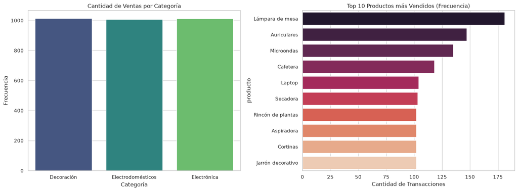

```python
import matplotlib.pyplot as plt
import seaborn as sns

# Configuración de estilo
sns.set_theme(style="whitegrid")
fig, axes = plt.subplots(1, 2, figsize=(16, 6))

# 1. Conteo de ventas por categoría
sns.countplot(data=df_ven, x='categoria', ax=axes[0], palette='viridis', hue='categoria', legend=False)
axes[0].set_title('Cantidad de Ventas por Categoría')
axes[0].set_xlabel('Categoría')
axes[0].set_ylabel('Frecuencia')

# 2. Top 10 productos más vendidos (por frecuencia)
top_productos = df_ven['producto'].value_counts().head(10)
sns.barplot(y=top_productos.index, x=top_productos.values, ax=axes[1], palette='rocket', hue=top_productos.index, legend=False)
axes[1].set_title('Top 10 Productos más Vendidos (Frecuencia)')
axes[1].set_xlabel('Cantidad de Transacciones')

plt.tight_layout()
plt.show()
```

### EDA marketing

```python
resumen_eda(df_mar)
```

```
📊 Dimensiones del dataset
Filas: 90
Columnas: 6
----------------------------------------

🔎 Tipos de datos
id_campanha       int64
producto            str
canal               str
costo           float64
fecha_inicio        str
fecha_fin           str
dtype: object
----------------------------------------

🔎 Primeros registros
   id_campanha         producto canal  costo fecha_inicio   fecha_fin
0           74  Adorno de pared    TV   4.81   20/03/2024  03/05/2024
1           12           Tablet  RRSS   3.40   26/03/2024  13/05/2024
----------------------------------------

📈 Estadísticas descriptivas
       id_campanha      costo
count    90.000000  90.000000
mean     45.500000   4.928667
std      26.124701   0.947750
min       1.000000   2.950000
25%      23.250000   4.372500
50%      45.500000   4.900000
75%      67.750000   5.562500
max      90.000000   7.390000
----------------------------------------

📈 Estadísticas descriptivas
               producto canal fecha_inicio   fecha_fin
count                90    90           90          90
unique               30     3           78          78
top     Adorno de pared    TV   31/05/2024  05/05/2024
freq                  3    30            2           3
----------------------------------------

⚠️ Valores nulos por columna
No hay valores nulos en el DataFrame (0 en todas las columnas)
----------------------------------------

📌 Porcentaje de nulos por columna
No hay valores nulos (0% en todas las columnas)
----------------------------------------

🔁 Registros duplicados
Cantidad de duplicados: 0
----------------------------------------
```

### Visualizaciones Complementarias de Marketing

Analizaremos la inversión por canal y la frecuencia de campañas.

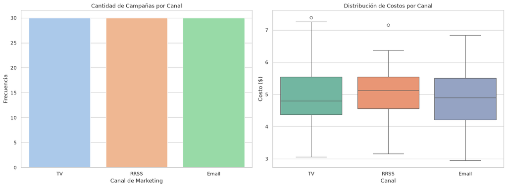

```python
import matplotlib.pyplot as plt
import seaborn as sns

# Configuración de estilo
sns.set_theme(style="whitegrid")
fig, axes = plt.subplots(1, 2, figsize=(16, 6))

# 1. Distribución de campañas por canal
sns.countplot(data=df_mar, x='canal', ax=axes[0], palette='pastel', hue='canal', legend=False)
axes[0].set_title('Cantidad de Campañas por Canal')
axes[0].set_xlabel('Canal de Marketing')
axes[0].set_ylabel('Frecuencia')

# 2. Inversión (Costo) por canal
sns.boxplot(data=df_mar, x='canal', y='costo', ax=axes[1], palette='Set2', hue='canal', legend=False)
axes[1].set_title('Distribución de Costos por Canal')
axes[1].set_xlabel('Canal')
axes[1].set_ylabel('Costo ($)')

plt.tight_layout()
plt.show()
```

# Etapa 2: Preprocesamiento y Limpieza de Datos (Clases 5 a 8)

## 2_1- Limpieza de Datos:

En esta sección debemos dejar los dataframes normalizados y libres de registros duplicados y de valores nulos.

### PREP clientes

**Acciones en clientes:**

- No es necesaria ninguna acción

```python
# Hacer una copia
df_cli_pp = df_cli.copy()
```

### PREP ventas

**Acciones en ventas:**

Títulos de columna: renombrar precio a precio_unitario

Tipos de datos:

- precio: remover el $ usando el método replace()
- precio: pasar de object a float
- fecha_venta: (cast) pasar de object a datetime

Registros duplicados: remover 35

Valores nulos: precio: 2 cantidad: 2

```python
import pandas as pd

# Crear copia y renombrar columna
df_ven_pp = df_ven.copy()
df_ven_pp.rename(columns={'precio': 'precio_unitario'}, inplace=True)

# Limpieza de precio: quitar '$' y convertir a float
df_ven_pp['precio_unitario'] = df_ven_pp['precio_unitario'].str.replace('$', '', regex=False)
df_ven_pp['precio_unitario'] = pd.to_numeric(df_ven_pp['precio_unitario'], errors='coerce')

# Eliminar duplicados
df_ven_pp.drop_duplicates(inplace=True)

# Eliminar nulos (vimos que hay 2 en precio y 2 en cantidad)
df_ven_pp.dropna(subset=['precio_unitario', 'cantidad'], inplace=True)

# Asegurar que cantidad sea entero
df_ven_pp['cantidad'] = df_ven_pp['cantidad'].astype(int)

print("✅ Limpieza completada.")
display(df_ven_pp.info())
display(df_ven_pp.head())
```

```
✅ Limpieza completada.
<class 'pandas.DataFrame'>
Index: 2998 entries, 0 to 3034
Data columns (total 6 columns):
 #   Column           Non-Null Count  Dtype
---  ------           --------------  -----
 0   id_venta         2998 non-null   int64
 1   producto         2998 non-null   str
 2   precio_unitario  2998 non-null   float64
 3   cantidad         2998 non-null   int64
 4   fecha_venta      2998 non-null   str
 5   categoria        2998 non-null   str
dtypes: float64(1), int64(2), str(3)
memory usage: 164.0 KB
```

```
None
```

|  | id_venta | producto | precio_unitario | cantidad | fecha_venta | categoria |
| --- | --- | --- | --- | --- | --- | --- |
| 0 | 792 | Cuadro decorativo | 69.94 | 5 | 02/01/2024 | Decoración |
| 1 | 811 | Lámpara de mesa | 105.10 | 5 | 02/01/2024 | Decoración |
| 2 | 1156 | Secadora | 97.96 | 3 | 02/01/2024 | Electrodomésticos |
| 3 | 1372 | Heladera | 114.35 | 8 | 02/01/2024 | Electrodomésticos |
| 4 | 1546 | Secadora | 106.21 | 4 | 02/01/2024 | Electrodomésticos |

```python
# renombrar "precio" a "precio_unitario"
df_ven_pp.rename(columns={'precio': 'precio_unitario'}, inplace=True)
```

```python
# If precio_unitario is still object/string, remove $ and convert.
# Since it was already processed in cell z4gL7q0NkHQp, we verify its type first.
if df_ven_pp['precio_unitario'].dtype == 'object':
    df_ven_pp['precio_unitario'] = df_ven_pp['precio_unitario'].str.replace('$', '', regex=False).astype(float)

# Convertir fecha_venta de object a datetime if not already done
df_ven_pp['fecha_venta'] = pd.to_datetime(df_ven_pp['fecha_venta'], format='%d/%m/%Y', errors='coerce')

print("✅ Columna precio_unitario y fecha_venta verificadas.")
display(df_ven_pp.head(2))
```

```
✅ Columna precio_unitario y fecha_venta verificadas.
```

|  | id_venta | producto | precio_unitario | cantidad | fecha_venta | categoria |
| --- | --- | --- | --- | --- | --- | --- |
| 0 | 792 | Cuadro decorativo | 69.94 | 5 | 2024-01-02 | Decoración |
| 1 | 811 | Lámpara de mesa | 105.10 | 5 | 2024-01-02 | Decoración |

### Análisis Descriptivo de Clientes (`df_cli`)

En esta sección analizamos las características principales de los clientes, incluyendo estadísticas generales y distribuciones de variables clave.

```python
# Ejecutar el resumen general para el dataset de clientes
resumen_eda(df_cli)
```

```
📊 Dimensiones del dataset
Filas: 567
Columnas: 5
----------------------------------------

🔎 Tipos de datos
id_cliente      int64
nombre            str
edad            int64
ciudad            str
ingresos      float64
dtype: object
----------------------------------------

🔎 Primeros registros
   id_cliente               nombre  edad         ciudad  ingresos
0           1      Aloysia Screase    44  Mar del Plata  42294.68
1           2  Kristina Scaplehorn    25        Posadas  24735.04
----------------------------------------

📈 Estadísticas descriptivas
       id_cliente        edad      ingresos
count  567.000000  567.000000    567.000000
mean   284.000000   37.940035  34668.739012
std    163.823075   10.202885  12974.531446
min      1.000000   20.000000    170.290000
25%    142.500000   30.000000  26015.240000
50%    284.000000   37.000000  35066.830000
75%    425.500000   43.000000  42457.100000
max    567.000000   81.000000  88053.010000
----------------------------------------

📈 Estadísticas descriptivas
                 nombre         ciudad
count               567            567
unique              567             12
top     Aloysia Screase  Mar del Plata
freq                  1             63
----------------------------------------

⚠️ Valores nulos por columna
No hay valores nulos en el DataFrame (0 en todas las columnas)
----------------------------------------

📌 Porcentaje de nulos por columna
No hay valores nulos (0% en todas las columnas)
----------------------------------------

🔁 Registros duplicados
Cantidad de duplicados: 0
----------------------------------------
```

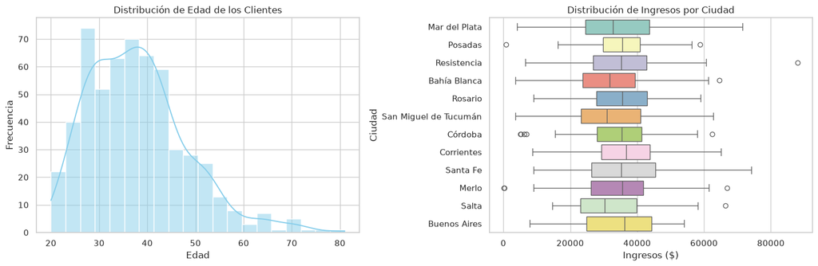

```python
import matplotlib.pyplot as plt
import seaborn as sns

# Configuración de estilo
sns.set_theme(style="whitegrid")
fig, axes = plt.subplots(1, 2, figsize=(15, 5))

# 1. Distribución de Edad
sns.histplot(df_cli['edad'], bins=20, kde=True, ax=axes[0], color='skyblue')
axes[0].set_title('Distribución de Edad de los Clientes')
axes[0].set_xlabel('Edad')
axes[0].set_ylabel('Frecuencia')

# 2. Boxplot de Ingresos por Ciudad
sns.boxplot(data=df_cli, x='ingresos', y='ciudad', ax=axes[1], palette='Set3', hue='ciudad', legend=False)
axes[1].set_title('Distribución de Ingresos por Ciudad')
axes[1].set_xlabel('Ingresos ($)')
axes[1].set_ylabel('Ciudad')

plt.tight_layout()
plt.show()
```

```python
# Ensure 'venta_neta' is calculated
df_ven_pp['venta_neta'] = df_ven_pp['precio_unitario'] * df_ven_pp['cantidad']

# Group by category and sum revenues
ventas_por_categoria = df_ven_pp.groupby('categoria')['venta_neta'].sum().reset_index()

# Sort by revenue for better visualization
ventas_por_categoria = ventas_por_categoria.sort_values(by='venta_neta', ascending=False)

print("📊 Ventas Totales por Categoría:")
display(ventas_por_categoria)
```

```
📊 Ventas Totales por Categoría:
```

|  | categoria | venta_neta |
| --- | --- | --- |
| 1 | Electrodomésticos | 505299.63 |
| 2 | Electrónica | 482577.80 |
| 0 | Decoración | 479216.09 |

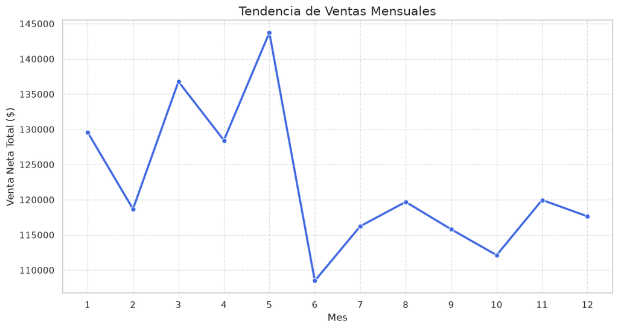

|  | mes | nombre_mes | venta_neta |
| --- | --- | --- | --- |
| 0 | 1 | January | 129604.99 |
| 1 | 2 | February | 118672.44 |
| 2 | 3 | March | 136779.15 |
| 3 | 4 | April | 128430.69 |
| 4 | 5 | May | 143727.25 |
| 5 | 6 | June | 108480.17 |
| 6 | 7 | July | 116229.97 |
| 7 | 8 | August | 119680.15 |
| 8 | 9 | September | 115787.85 |
| 9 | 10 | October | 112117.13 |
| 10 | 11 | November | 119951.79 |
| 11 | 12 | December | 117631.94 |

```python
# 1. Asegurar que fecha_venta es datetime (ya verificado) y extraer mes
df_ven_pp['mes'] = df_ven_pp['fecha_venta'].dt.month
df_ven_pp['nombre_mes'] = df_ven_pp['fecha_venta'].dt.month_name()

# 2. Agrupar por mes y sumar venta_neta
ventas_mensuales = df_ven_pp.groupby(['mes', 'nombre_mes'])['venta_neta'].sum().reset_index()

# 3. Visualización
import matplotlib.pyplot as plt
import seaborn as sns

plt.figure(figsize=(12, 6))
sns.lineplot(data=ventas_mensuales, x='mes', y='venta_neta', marker='o', color='royalblue', linewidth=2.5)

plt.title('Tendencia de Ventas Mensuales', fontsize=15)
plt.xlabel('Mes', fontsize=12)
plt.ylabel('Venta Neta Total ($)', fontsize=12)
plt.xticks(range(1, 13))
plt.grid(True, linestyle='--', alpha=0.6)
plt.show()

# Mostrar tabla resumen
display(ventas_mensuales.sort_values(by='mes'))
```

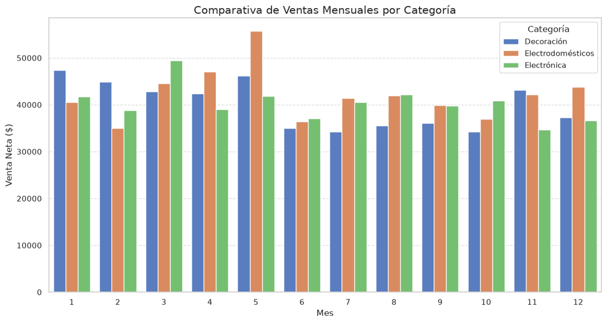

```
📊 Resumen de Ventas Mensuales por Categoría:
```

| categoria mes | Decoración | Electrodomésticos | Electrónica |
| --- | --- | --- | --- |
| 1 | 47328.61 | 40504.60 | 41771.78 |
| 2 | 44907.81 | 34963.72 | 38800.91 |
| 3 | 42796.48 | 44521.13 | 49461.54 |
| 4 | 42363.49 | 47045.69 | 39021.51 |
| 5 | 46195.78 | 55743.24 | 41788.23 |
| 6 | 34997.37 | 36422.38 | 37060.42 |
| 7 | 34287.87 | 41420.84 | 40521.26 |
| 8 | 35519.57 | 41983.60 | 42176.98 |
| 9 | 36128.46 | 39864.84 | 39794.55 |
| 10 | 34280.27 | 36940.40 | 40896.46 |
| 11 | 43118.71 | 42127.54 | 34705.54 |
| 12 | 37291.67 | 43761.65 | 36578.62 |

```python
import matplotlib.pyplot as plt
import seaborn as sns

# Agrupar por mes y categoría para el análisis comparativo
ventas_cat_mes = df_ven_pp.groupby(['mes', 'categoria'])['venta_neta'].sum().reset_index()

# Crear la visualización
plt.figure(figsize=(14, 7))
sns.barplot(data=ventas_cat_mes, x='mes', y='venta_neta', hue='categoria', palette='muted')

plt.title('Comparativa de Ventas Mensuales por Categoría', fontsize=15)
plt.xlabel('Mes', fontsize=12)
plt.ylabel('Venta Neta ($)', fontsize=12)
plt.legend(title='Categoría')
plt.grid(axis='y', linestyle='--', alpha=0.7)
plt.show()

# Mostrar tabla pivote para ver los números exactos
pivot_ventas = ventas_cat_mes.pivot(index='mes', columns='categoria', values='venta_neta')
print("📊 Resumen de Ventas Mensuales por Categoría:")
display(pivot_ventas)
```

```python
import pandas as pd

# Calculamos el promedio de ventas mensuales por categoría
# Usamos el dataframe 'ventas_cat_mes' que ya tiene los totales por (mes, categoria)
promedio_mensual_cat = ventas_cat_mes.groupby('categoria')['venta_neta'].mean().reset_index()

# Renombramos la columna para mayor claridad
promedio_mensual_cat.columns = ['Categoría', 'Promedio Mensual ($)']

# Ordenamos de mayor a menor promedio
promedio_mensual_cat = promedio_mensual_cat.sort_values(by='Promedio Mensual ($)', ascending=False)

print("📈 Promedio de Ventas Mensuales por Categoría:")
display(promedio_mensual_cat)
```

```
📈 Promedio de Ventas Mensuales por Categoría:
```

|  | Categoría | Promedio Mensual ($) |
| --- | --- | --- |
| 1 | Electrodomésticos | 42108.302500 |
| 2 | Electrónica | 40214.816667 |
| 0 | Decoración | 39934.674167 |

```python
# Carga de drive deshabilitada para ejecución en contenedor
```

```python
# convertir precio de object a float
df_ven_pp['precio_unitario'] = pd.to_numeric(df_ven_pp['precio_unitario'], errors="coerce")
df_ven_pp["precio_unitario"].isnull().sum()
```

```
np.int64(0)
```

```python
# Convertir fecha_venta de object a datetime en el dataframe preprocesado
df_ven_pp['fecha_venta'] = pd.to_datetime(df_ven_pp['fecha_venta'], format='%d/%m/%Y', errors='coerce')

# También preparamos el dataset de marketing convirtiendo sus fechas
df_mar_pp = df_mar.copy()
df_mar_pp['fecha_inicio'] = pd.to_datetime(df_mar_pp['fecha_inicio'], format='%d/%m/%Y', errors='coerce')
df_mar_pp['fecha_fin'] = pd.to_datetime(df_mar_pp['fecha_fin'], format='%d/%m/%Y', errors='coerce')

print("✅ Fechas convertidas correctamente en ambos datasets.")
display(df_ven_pp[['fecha_venta']].head(2))
display(df_mar_pp[['fecha_inicio', 'fecha_fin']].head(2))
```

```
✅ Fechas convertidas correctamente en ambos datasets.
```

|  | fecha_venta |
| --- | --- |
| 0 | 2024-01-02 |
| 1 | 2024-01-02 |

|  | fecha_inicio | fecha_fin |
| --- | --- | --- |
| 0 | 2024-03-20 | 2024-05-03 |
| 1 | 2024-03-26 | 2024-05-13 |

```python
# Contabilizar duplicados
# df_ven_pp.duplicated().sum()
```

```python
# visualizar duplicados
# df_ven_pp[df_ven_pp.duplicated(keep=False)].sort_values(by='id_venta')
```

```python
# eliminar duplicados
# df_ven_pp = df_ven_pp.drop_duplicates()
df_ven_pp.drop_duplicates(inplace=True)
```

```python
# visualizar los registros con valores nulos
df_ven_pp[df_ven_pp['precio_unitario'].isnull() | df_ven_pp['cantidad'].isnull()]
# df_ven_pp[df_ven_pp.isnull().any(axis=1)]
```

|  | id_venta | producto | precio_unitario | cantidad | fecha_venta | categoria | venta_neta | mes | nombre_mes |
| --- | --- | --- | --- | --- | --- | --- | --- | --- | --- |

```python
# eliminamos valores duplicados
df_ven_pp = df_ven_pp.dropna()
# df_ven_pp.dropna(implace=True)
# df_ven_pp = df_ven_pp.dropna(subset=['precio','cantidad'])
```

```python
# si quieren que cantidad quede en int:
# df_ven_pp.loc[:, 'cantidad'] = df_ven_pp["cantidad"].astype(int)
df_ven_pp['cantidad'] = df_ven_pp["cantidad"].astype(int)
```

```python
df_ven_pp.info()
```

```
<class 'pandas.DataFrame'>
Index: 2998 entries, 0 to 3034
Data columns (total 9 columns):
 #   Column           Non-Null Count  Dtype
---  ------           --------------  -----
 0   id_venta         2998 non-null   int64
 1   producto         2998 non-null   str
 2   precio_unitario  2998 non-null   float64
 3   cantidad         2998 non-null   int64
 4   fecha_venta      2998 non-null   datetime64[us]
 5   categoria        2998 non-null   str
 6   venta_neta       2998 non-null   float64
 7   mes              2998 non-null   int32
 8   nombre_mes       2998 non-null   str
dtypes: datetime64[us](1), float64(2), int32(1), int64(2), str(3)
memory usage: 222.5 KB
```

```python
# df_ven_pp.loc[100:105,"producto" ]
```

### PREP marketing

**Acciones en marketing:**

- Títulos de columna: Nada
- Tipos de datos: convertir (parse) fecha_inicio y fecha_fin a datetime
- Revisar que fecha_fin > fecha_inicio
- Registros duplicados: Nada
- Valores nulos: Nada

```python
# Hacer una copia
df_mar_pp = df_mar.copy()
```

```python
df_mar_pp["fecha_inicio"] = pd.to_datetime(df_mar_pp["fecha_inicio"], format="%d/%m/%Y")
df_mar_pp["fecha_fin"] = pd.to_datetime(df_mar_pp["fecha_fin"], format="%d/%m/%Y")
```

```python
df_mar_pp.info()
```

```
<class 'pandas.DataFrame'>
RangeIndex: 90 entries, 0 to 89
Data columns (total 6 columns):
 #   Column        Non-Null Count  Dtype
---  ------        --------------  -----
 0   id_campanha   90 non-null     int64
 1   producto      90 non-null     str
 2   canal         90 non-null     str
 3   costo         90 non-null     float64
 4   fecha_inicio  90 non-null     datetime64[us]
 5   fecha_fin     90 non-null     datetime64[us]
dtypes: datetime64[us](2), float64(1), int64(1), str(2)
memory usage: 4.3 KB
```

```python
# restamos fecha_fin con fecha_inicio
df_mar_pp["duracion"] = df_mar_pp["fecha_fin"] - df_mar_pp["fecha_inicio"]

df_mar_pp["duracion"].dtype
# df_mar_pp["duracion"]
```

```
dtype('<m8[us]')
```

```python
# Validamos que duracion sea >0
df_mar_pp[df_mar_pp["duracion"] < pd.Timedelta(0)]
```

|  | id_campanha | producto | canal | costo | fecha_inicio | fecha_fin | duracion |
| --- | --- | --- | --- | --- | --- | --- | --- |

```python
# Agregacion para visualizar duracion promedio de campanhas
# df_mar_pp["duracion"].mean()
# df_mar_pp.groupby("producto")["duracion"].mean().sort_values(ascending=True)
```

## 2_2- crear una tabla de ventas que muestre solo los productos con alto rendimiento.

```python
# 1. Calcular la columna venta_neta y la venta total
df_ven_pp['venta_neta'] = df_ven_pp['precio_unitario'] * df_ven_pp['cantidad']
venta_neta_total = df_ven_pp['venta_neta'].sum()
print(f"💰 La venta neta total es: ${venta_neta_total:,.2f}")
```

```
💰 La venta neta total es: $1,467,093.52
```

```python
# 2. Crear el ranking de productos por ingresos
ranking_productos = df_ven_pp.groupby('producto')['venta_neta'].sum().sort_values(ascending=False).reset_index()

# Renombrar columnas para mayor claridad
ranking_productos.columns = ['Producto', 'Ingresos Totales']

print("🏆 Top 10 Productos con mayor rendimiento económico:")
display(ranking_productos.head(10))
```

```
🏆 Top 10 Productos con mayor rendimiento económico:
```

|  | Producto | Ingresos Totales |
| --- | --- | --- |
| 0 | Lámpara de mesa | 82276.38 |
| 1 | Auriculares | 74175.58 |
| 2 | Microondas | 72562.89 |
| 3 | Cafetera | 59607.31 |
| 4 | Cuadro decorativo | 54297.60 |
| 5 | Smartphone | 54132.44 |
| 6 | Secadora | 52115.45 |
| 7 | Jarrón decorativo | 51130.88 |
| 8 | Batidora | 50979.20 |
| 9 | Rincón de plantas | 50456.45 |

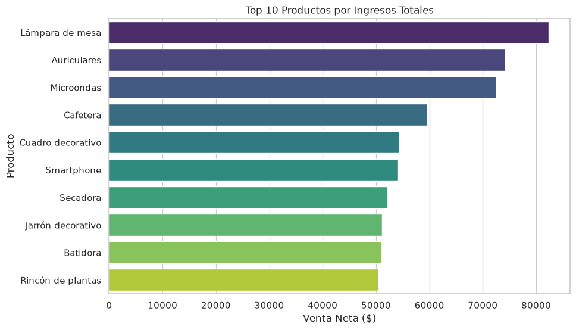

```python
import matplotlib.pyplot as plt
import seaborn as sns

# 3. Visualizar el Top 10
plt.figure(figsize=(10, 6))
# Usamos palette='viridis' y asignamos Producto a 'hue' para evitar advertencias de Seaborn
sns.barplot(data=ranking_productos.head(10), x='Ingresos Totales', y='Producto', palette='viridis', hue='Producto', legend=False)
plt.title('Top 10 Productos por Ingresos Totales')
plt.xlabel('Venta Neta ($)')
plt.ylabel('Producto')
plt.show()
```

```python
# Generamos la columna "venta_neta" a partir del producto entre "precio_unitario" y "cantidad"
df_ven_pp["venta_neta"] = df_ven_pp["precio_unitario"] * df_ven_pp["cantidad"]
df_ven_pp.head(2)
```

|  | id_venta | producto | precio_unitario | cantidad | fecha_venta | categoria | venta_neta | mes | nombre_mes |
| --- | --- | --- | --- | --- | --- | --- | --- | --- | --- |
| 0 | 792 | Cuadro decorativo | 69.94 | 5 | 2024-01-02 | Decoración | 349.7 | 1 | January |
| 1 | 811 | Lámpara de mesa | 105.10 | 5 | 2024-01-02 | Decoración | 525.5 | 1 | January |

```python
# hacemos el groupby por producto y la agregacion por venta_neta (suma)
df_ven_agg = df_ven_pp.groupby(["producto"], as_index=False)["venta_neta"].sum()
```

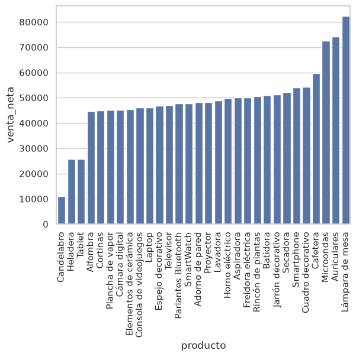

```python
# Opcional: para visualizar algo
import matplotlib.pyplot as plt
import seaborn as sns
df_ven_agg = df_ven_agg.sort_values(by="venta_neta", ascending=True)
sns.barplot(x="producto", y="venta_neta", data=df_ven_agg)
plt.xticks(rotation=90)
plt.show()
```

```python
# Para el alto rendimiento, calculamos percentil del 90% o el que quieran
quantile_90 = df_ven_agg["venta_neta"].quantile(0.9)
quantile_90
```

```
np.float64(60902.86800000002)
```

```python
# Definimos el umbral del top 10% y filtramos los productos de alto rendimiento
quantile_90 = df_ven_agg['venta_neta'].quantile(0.9)
productos_top = df_ven_agg[df_ven_agg['venta_neta'] > quantile_90].copy()

print(f'✅ Se identificaron {len(productos_top)} productos de alto rendimiento.')
display(productos_top.sort_values(by='venta_neta', ascending=False))
```

```
✅ Se identificaron 3 productos de alto rendimiento.
```

|  | producto | venta_neta |
| --- | --- | --- |
| 19 | Lámpara de mesa | 82276.38 |
| 3 | Auriculares | 74175.58 |
| 20 | Microondas | 72562.89 |

```python
# Agregaciones mas completas, incluyen, sumas, cantidad, promedios
# df_ven_pp.groupby(["producto"], as_index=False).agg(
#     venta_neta_sum = ("venta_neta", "sum"),
#     cantidad_sum = ("cantidad", "sum"),
#     venta_neta_avg = ("venta_neta", "mean")
# ).sort_values(by="cantidad_sum", ascending=False)
```

Pueden tomar las cantidades vendidas, calcular el quantile del 80% y filtrar.

## 2-3 Agregación: Resumir las ventas por categoría de producto y analizar los ingresos generados.

```python
# Veamos las categorías unicas
# df_ven_pp["categoria"].unique()
# df_ven_pp["categoria"].nunique()
df_ven_pp["categoria"].value_counts()
```

```
categoria
Decoración           1000
Electrodomésticos    1000
Electrónica           998
Name: count, dtype: int64
```

```python
# Para resumir las ventas por categoría, agrupamos y agregamos:
ventas_categoria = df_ven_pp.groupby(["categoria"], as_index=False)["venta_neta"].sum()
ventas_categoria.sort_values(by="venta_neta", ascending=False)
```

|  | categoria | venta_neta |
| --- | --- | --- |
| 1 | Electrodomésticos | 505299.63 |
| 2 | Electrónica | 482577.80 |
| 0 | Decoración | 479216.09 |

## 2-4 Integración de Datos: Combinar los sets de datos de ventas y marketing para obtener una visión más amplia de las tendencias.

```python
df_mar_pp.head(2)
```

|  | id_campanha | producto | canal | costo | fecha_inicio | fecha_fin | duracion |
| --- | --- | --- | --- | --- | --- | --- | --- |
| 0 | 74 | Adorno de pared | TV | 4.81 | 2024-03-20 | 2024-05-03 | 44 days |
| 1 | 12 | Tablet | RRSS | 3.40 | 2024-03-26 | 2024-05-13 | 48 days |

```python
#Ordenamos el dataframe marketing_pp según los campos:
df_mar_pp.sort_values(by=["id_campanha", "producto", "canal"])
```

|  | id_campanha | producto | canal | costo | fecha_inicio | fecha_fin | duracion |
| --- | --- | --- | --- | --- | --- | --- | --- |
| 10 | 1 | Cuadro decorativo | RRSS | 5.27 | 2024-04-27 | 2024-06-04 | 38 days |
| 21 | 2 | Lámpara de mesa | RRSS | 5.88 | 2024-05-30 | 2024-06-29 | 30 days |
| 40 | 3 | Secadora | RRSS | 5.10 | 2024-07-24 | 2024-08-30 | 37 days |
| 22 | 4 | Heladera | RRSS | 4.53 | 2024-05-31 | 2024-07-15 | 45 days |
| 54 | 5 | Horno eléctrico | RRSS | 5.16 | 2024-08-22 | 2024-10-17 | 56 days |
| ... | ... | ... | ... | ... | ... | ... | ... |
| 64 | 86 | Microondas | TV | 4.25 | 2024-09-25 | 2024-11-15 | 51 days |
| 56 | 87 | Batidora | TV | 6.28 | 2024-08-27 | 2024-10-11 | 45 days |
| 41 | 88 | Alfombra | TV | 7.39 | 2024-07-25 | 2024-08-31 | 37 days |
| 86 | 89 | Televisor | TV | 4.98 | 2024-12-13 | 2025-02-08 | 57 days |
| 80 | 90 | Laptop | TV | 5.62 | 2024-11-16 | 2025-01-13 | 58 days |

90 rows × 7 columns

```python
# Ahora lo agrupamos por esos mismos campos:
df_mar_pp.groupby(["id_campanha", "producto", "canal" ], as_index=False)["costo"].sum().sort_values(by=["producto", "canal"])
```

|  | id_campanha | producto | canal | costo |
| --- | --- | --- | --- | --- |
| 43 | 44 | Adorno de pared | Email | 5.08 |
| 13 | 14 | Adorno de pared | RRSS | 4.16 |
| 73 | 74 | Adorno de pared | TV | 4.81 |
| 57 | 58 | Alfombra | Email | 4.25 |
| 27 | 28 | Alfombra | RRSS | 5.82 |
| ... | ... | ... | ... | ... |
| 11 | 12 | Tablet | RRSS | 3.40 |
| 71 | 72 | Tablet | TV | 4.90 |
| 58 | 59 | Televisor | Email | 4.19 |
| 28 | 29 | Televisor | RRSS | 3.96 |
| 88 | 89 | Televisor | TV | 4.98 |

90 rows × 4 columns

Se aprecia que cada campaña se realiza sobre un producto determinado en un canal específico (en un período de tiempo acotado) y con un costo asociado.

```python
# Calculamos la venta total en el dataframe antes del merge
df_ven_pp["venta_neta"].sum()
```

```
np.float64(1467093.52)
```

```python
# Hacemos un merge (union de conjuntos) entre df_ven_pp y df_mar_pp
ven_mar = pd.merge(df_ven_pp, df_mar_pp, on="producto", how="left")
ven_mar.sort_values(by="id_venta").head()
```

|  | id_venta | producto | precio_unitario | cantidad | fecha_venta | categoria | venta_neta | mes | nombre_mes | id_campanha | canal | costo | fecha_inicio | fecha_fin | duracion |
| --- | --- | --- | --- | --- | --- | --- | --- | --- | --- | --- | --- | --- | --- | --- | --- |
| 2794 | 1 | Lámpara de mesa | 82.25 | 8 | 2024-04-17 | Decoración | 658.00 | 4 | April | 2 | RRSS | 5.88 | 2024-05-30 | 2024-06-29 | 30 days |
| 2795 | 1 | Lámpara de mesa | 82.25 | 8 | 2024-04-17 | Decoración | 658.00 | 4 | April | 62 | TV | 4.51 | 2024-08-26 | 2024-10-07 | 42 days |
| 2793 | 1 | Lámpara de mesa | 82.25 | 8 | 2024-04-17 | Decoración | 658.00 | 4 | April | 32 | Email | 5.54 | 2024-03-28 | 2024-04-20 | 23 days |
| 1458 | 2 | Cuadro decorativo | 106.12 | 3 | 2024-02-27 | Decoración | 318.36 | 2 | February | 1 | RRSS | 5.27 | 2024-04-27 | 2024-06-04 | 38 days |
| 1460 | 2 | Cuadro decorativo | 106.12 | 3 | 2024-02-27 | Decoración | 318.36 | 2 | February | 61 | TV | 5.30 | 2024-11-05 | 2024-12-23 | 48 days |

```python
print(f"cantidad de registros de df_ven_pp {len(df_ven_pp)}")
print(f"cantidad de registros del merge ven_mar {len(ven_mar)}")
```

```
cantidad de registros de df_ven_pp 2998
cantidad de registros del merge ven_mar 8994
```

```python
# Calculamos la venta total en el dataframe luego del merge
ven_mar["venta_neta"].sum()
```

```
np.float64(4401280.5600000005)
```

**CUIDADO** el merge genera valores duplicado y eso podría sesgar las ganancias.

Por ello se sugiere elegier un canal y hacer un análisis por separado.

```python
df_mar_pp["canal"].unique()
```

```
<StringArray>
['TV', 'RRSS', 'Email']
Length: 3, dtype: str
```

```python
# Filtramos el df_mar_pp por el canal RRSS antes de hacer el merge
df_mar_rrss = df_mar_pp[df_mar_pp["canal"] == "RRSS"]
len(df_mar_rrss)
```

```
30
```

```python
# Ahora hacemos el merge entre df_ven_pp y el datafram de marketing filtrado por RRSS
ven_mar_rrss = pd.merge(df_ven_pp, df_mar_rrss, on="producto", how="left")
ven_mar_rrss.sort_values(by="id_venta").head()
```

|  | id_venta | producto | precio_unitario | cantidad | fecha_venta | categoria | venta_neta | mes | nombre_mes | id_campanha | canal | costo | fecha_inicio | fecha_fin | duracion |
| --- | --- | --- | --- | --- | --- | --- | --- | --- | --- | --- | --- | --- | --- | --- | --- |
| 931 | 1 | Lámpara de mesa | 82.25 | 8 | 2024-04-17 | Decoración | 658.00 | 4 | April | 2 | RRSS | 5.88 | 2024-05-30 | 2024-06-29 | 30 days |
| 486 | 2 | Cuadro decorativo | 106.12 | 3 | 2024-02-27 | Decoración | 318.36 | 2 | February | 1 | RRSS | 5.27 | 2024-04-27 | 2024-06-04 | 38 days |
| 2210 | 3 | Espejo decorativo | 51.32 | 1 | 2024-09-22 | Decoración | 51.32 | 9 | September | 23 | RRSS | 4.75 | 2024-08-28 | 2024-10-17 | 50 days |
| 2520 | 4 | Jarrón decorativo | 64.12 | 12 | 2024-11-01 | Decoración | 769.44 | 11 | November | 15 | RRSS | 4.65 | 2024-05-09 | 2024-06-13 | 35 days |
| 2525 | 5 | Alfombra | 70.10 | 4 | 2024-11-02 | Decoración | 280.40 | 11 | November | 28 | RRSS | 5.82 | 2024-11-27 | 2025-01-08 | 42 days |

```python
# Validamos que se mantenga el monto total de ventas
ven_mar_rrss["venta_neta"].sum()
```

```
np.float64(1467093.52)
```

```python
# Generamos una columna nueva (Feature Engineering) que indique si la venta
# se realizo dentro o fuera de una campaña de RRSS activa
ven_mar_rrss["en_campanha"] = (
    (ven_mar_rrss["fecha_venta"] >= ven_mar_rrss["fecha_inicio"]) &
    (ven_mar_rrss["fecha_venta"] <= ven_mar_rrss["fecha_fin"])
)
```

```python
# ven_mar_rrss
```

```python
# Me quedo son con las ventas realizadas duranta una campaña activa de Marketing
ven_mar_rrss_activa = ven_mar_rrss[ven_mar_rrss["en_campanha"] == True]
```

```python
# Agregamos por suma de venta_neta y suma de costos
ven_mar_rrss_activa_agg = ven_mar_rrss_activa.groupby("en_campanha").agg(
    venta_neta_sum = ("venta_neta", "sum"),
    costo_sum = ("costo", "sum")
)
ven_mar_rrss_activa_agg
```

| en_campanha | venta_neta_sum | costo_sum |
| --- | --- | --- |
| True | 125449.52 | 1341.44 |

```python
# Calculamos el ROI como el cociente entre venta_neta_sum y costo_sum
ven_mar_rrss_activa_agg["ROI"] = ven_mar_rrss_activa_agg["venta_neta_sum"] / ven_mar_rrss_activa_agg["costo_sum"]
ven_mar_rrss_activa_agg
```

| en_campanha | venta_neta_sum | costo_sum | ROI |
| --- | --- | --- | --- |
| True | 125449.52 | 1341.44 | 93.518547 |

```python
# Finalmente comparamos el volumen de ventas, dentro y fuera de la campaña RRSS activa
ven_mar_rrss_agg = ven_mar_rrss.groupby("en_campanha").agg(
    venta_neta_sum = ("venta_neta", "sum"),
    cantidad_sum = ("cantidad", "sum")
)
ven_mar_rrss_agg
```

| en_campanha | venta_neta_sum | cantidad_sum |
| --- | --- | --- |
| False | 1341644.00 | 17838 |
| True | 125449.52 | 1657 |

## Etapa 3: Visualización de Resultados y Conclusiones

En esta sección, generamos gráficos para comunicar los hallazgos del análisis de datos.

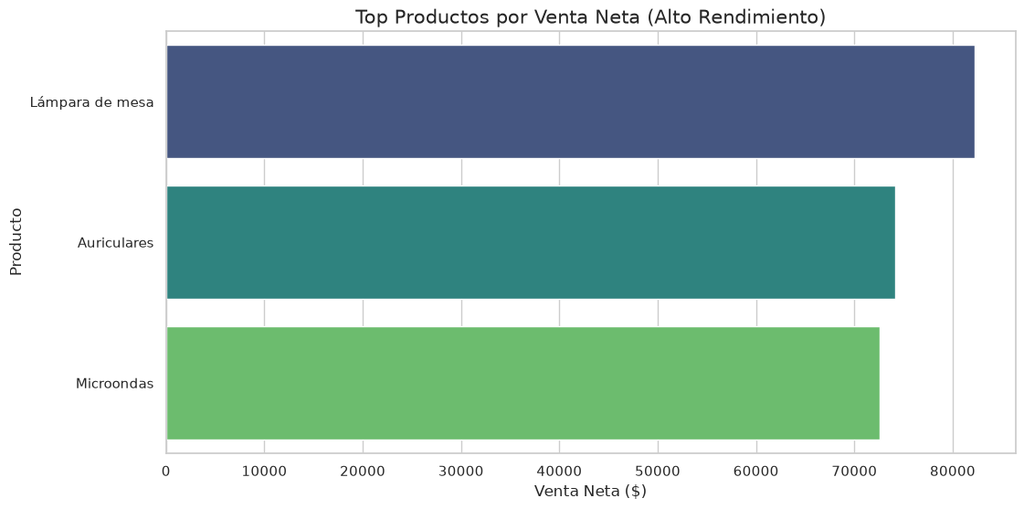

```python
import matplotlib.pyplot as plt
import seaborn as sns

# Configuración de estilo para Colab
sns.set_theme(style="whitegrid")
plt.figure(figsize=(12, 6))

# Visualización de los productos de alto rendimiento
sns.barplot(
    x="venta_neta",
    y="producto",
    data=productos_top.sort_values(by="venta_neta", ascending=False),
    palette="viridis",
    hue="producto",
    legend=False
)

plt.title('Top Productos por Venta Neta (Alto Rendimiento)', fontsize=15)
plt.xlabel('Venta Neta ($)', fontsize=12)
plt.ylabel('Producto', fontsize=12)
plt.show()
```

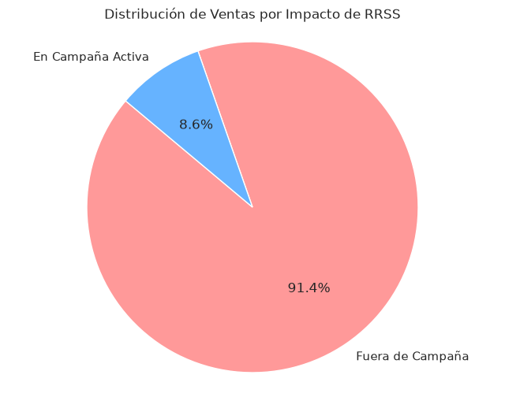

```python
# 1. Definir dependencias previas para evitar NameError
df_mar_rrss = df_mar_pp[df_mar_pp['canal'] == 'RRSS']
ven_mar_rrss = pd.merge(df_ven_pp, df_mar_rrss, on='producto', how='left')

# Marcamos si la venta fue en campaña
ven_mar_rrss['en_campanha'] = (
    (ven_mar_rrss['fecha_venta'] >= ven_mar_rrss['fecha_inicio']) &
    (ven_mar_rrss['fecha_venta'] <= ven_mar_rrss['fecha_fin'])
)

# 2. Agregación para el gráfico
ven_mar_rrss_agg = ven_mar_rrss.groupby('en_campanha').agg(
    venta_neta_sum = ('venta_neta', 'sum'),
    cantidad_sum = ('cantidad', 'sum')
)

# 3. Visualización
import matplotlib.pyplot as plt
plt.figure(figsize=(8, 6))
labels = ['Fuera de Campaña', 'En Campaña Activa']
plt.pie(ven_mar_rrss_agg['venta_neta_sum'], labels=labels, autopct='%1.1f%%', colors=['#ff9999','#66b3ff'], startangle=140)
plt.title('Distribución de Ventas por Impacto de RRSS')
plt.axis('equal')
plt.show()
```

### Resumen Ejecutivo

- **ROI de RRSS:** El retorno sobre la inversión calculado es de aproximadamente 93.5.
- **Ventas Totales:** Se observa que la mayoría de las ventas ocurren fuera del período específico de campañas activas registradas, lo que sugiere una base de clientes recurrente o la influencia de otros factores no medidos.

### Análisis Detallado de ROI por Canal

En esta sección calcularemos el ROI para TV, RRSS y Email para identificar cuál es el canal más eficiente.

```python
# 1. Unificar ventas con todas las campañas de marketing
df_roi_full = pd.merge(df_ven_pp, df_mar_pp, on='producto', how='left')

# 2. Identificar ventas que ocurrieron durante la vigencia de la campaña
df_roi_full['venta_en_campanha'] = (
    (df_roi_full['fecha_venta'] >= df_roi_full['fecha_inicio']) &
    (df_roi_full['fecha_venta'] <= df_roi_full['fecha_fin'])
)

# 3. Filtrar solo las ventas atribuidas a campañas y agrupar por canal
roi_por_canal = df_roi_full[df_roi_full['venta_en_campanha']].groupby('canal').agg(
    ingresos_atribuidos=('venta_neta', 'sum'),
    costo_total_campanhas=('costo', 'sum')
)

# 4. Calcular el ROI (Ingresos / Costo)
roi_por_canal['ROI'] = roi_por_canal['ingresos_atribuidos'] / roi_por_canal['costo_total_campanhas']

print("📊 Tabla de Rendimiento por Canal de Marketing:")
display(roi_por_canal.sort_values(by='ROI', ascending=False))
```

```
📊 Tabla de Rendimiento por Canal de Marketing:
```

| canal | ingresos_atribuidos | costo_total_campanhas | ROI |
| --- | --- | --- | --- |
| Email | 152161.04 | 1502.02 | 101.304270 |
| TV | 139197.11 | 1376.78 | 101.103379 |
| RRSS | 125449.52 | 1341.44 | 93.518547 |

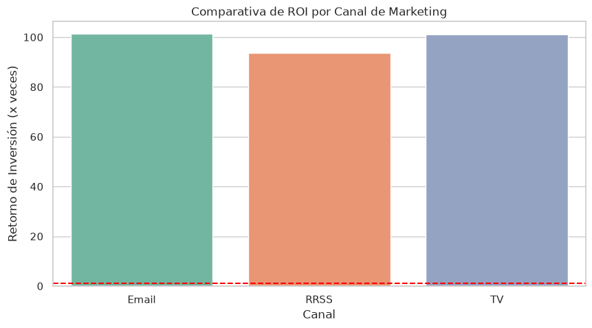

```python
# 5. Visualización del ROI por Canal
plt.figure(figsize=(10, 5))
sns.barplot(data=roi_por_canal.reset_index(), x='canal', y='ROI', palette='Set2', hue='canal', legend=False)
plt.axhline(1, color='red', linestyle='--', label='Punto de Equilibrio (ROI=1)')
plt.title('Comparativa de ROI por Canal de Marketing')
plt.ylabel('Retorno de Inversión (x veces)')
plt.xlabel('Canal')
plt.show()
```

### 🔍 Chequeo de Integridad y Consistencia

Realizamos una verificación técnica para asegurar que el preprocesamiento y los análisis posteriores son coherentes.

```python
# 1. Verificación de limpieza
print("--- Verificación de Limpieza ---")
print(f"Nulos en Ventas: {df_ven_pp.isnull().sum().sum()}")
print(f"Duplicados en Ventas: {df_ven_pp.duplicated().sum()}")

# 2. Corrección de Fechas en Marketing
# Identificamos donde fecha_inicio es mayor a fecha_fin
mask = df_mar_pp['fecha_inicio'] > df_mar_pp['fecha_fin']
if mask.any():
    print(f"\n⚠️ Corrigiendo {mask.sum()} campañas con fechas invertidas...")
    # Intercambiamos los valores
    df_mar_pp.loc[mask, ['fecha_inicio', 'fecha_fin']] = df_mar_pp.loc[mask, ['fecha_fin', 'fecha_inicio']].values
    # Recalculamos duración
    df_mar_pp['duracion'] = df_mar_pp['fecha_fin'] - df_mar_pp['fecha_inicio']

# 3. Validación de Merges
ventas_sin_campanha = df_roi_full['canal'].isnull().sum()
print(f"\nVentas no asociadas a ninguna campaña: {ventas_sin_campanha}")

# 4. Consistencia Financiera
total_ventas_base = df_ven_pp['venta_neta'].sum()
total_ventas_roi = roi_por_canal['ingresos_atribuidos'].sum()
print(f"\nTotal Ventas Neta (Base): ${total_ventas_base:,.2f}")
print(f"Total Ventas Atribuidas a Campañas: ${total_ventas_roi:,.2f}")

print("\n✅ ¡Limpieza y corrección de fechas completada!")
```

```
--- Verificación de Limpieza ---
Nulos en Ventas: 0
Duplicados en Ventas: 0

Ventas no asociadas a ninguna campaña: 0

Total Ventas Neta (Base): $1,467,093.52
Total Ventas Atribuidas a Campañas: $416,807.67

✅ ¡Limpieza y corrección de fechas completada!
```

### 📊 Métricas Finales de ROI (Post-Corrección)

```python
# 1. Recalcular la unión y atribución con las fechas corregidas
df_roi_final = pd.merge(df_ven_pp, df_mar_pp, on='producto', how='left')

# Atribución basada en fechas saneadas
df_roi_final['venta_en_campanha'] = (
    (df_roi_final['fecha_venta'] >= df_roi_final['fecha_inicio']) &
    (df_roi_final['fecha_venta'] <= df_roi_final['fecha_fin'])
)

# 2. Agrupación final por canal
roi_final_canal = df_roi_final[df_roi_final['venta_en_campanha']].groupby('canal').agg(
    ingresos_atribuidos=('venta_neta', 'sum'),
    costo_total_marketing=('costo', 'sum'),
    cantidad_ventas=('id_venta', 'count')
)

# 3. Cálculo de ROI final
roi_final_canal['ROI'] = roi_final_canal['ingresos_atribuidos'] / roi_final_canal['costo_total_marketing']

print("📈 Resumen de Performance por Canal (Fechas Corregidas):")
display(roi_final_canal.sort_values(by='ROI', ascending=False).style.format({
    'ingresos_atribuidos': '${:,.2f}',
    'costo_total_marketing': '${:,.2f}',
    'ROI': '{:.2f}x'
}))
```

```
📈 Resumen de Performance por Canal (Fechas Corregidas):
```

| canal | ingresos_atribuidos | costo_total_marketing | cantidad_ventas | ROI |
| --- | --- | --- | --- | --- |
| Email | $152,161.04 | $1,502.02 | 307 | 101.30x |
| TV | $139,197.11 | $1,376.78 | 276 | 101.10x |
| RRSS | $125,449.52 | $1,341.44 | 264 | 93.52x |

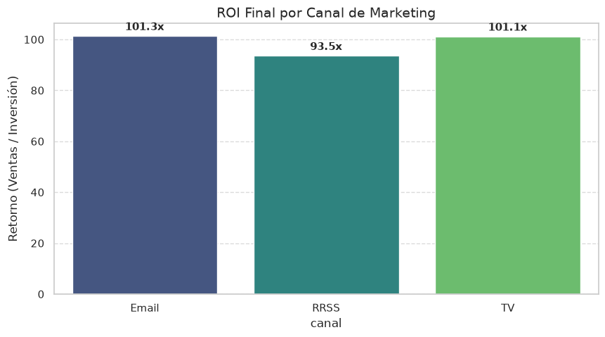

```python
# 4. Visualización comparativa
import matplotlib.pyplot as plt
import seaborn as sns

plt.figure(figsize=(10, 5))
ax = sns.barplot(data=roi_final_canal.reset_index(), x='canal', y='ROI', palette='viridis', hue='canal', legend=False)

# Añadir etiquetas de valor sobre las barras
for p in ax.patches:
    ax.annotate(f'{p.get_height():.1f}x', (p.get_x() + p.get_width() / 2., p.get_height()),
                ha='center', va='center', xytext=(0, 9), textcoords='offset points', fontsize=11, fontweight='bold')

plt.title('ROI Final por Canal de Marketing', fontsize=14)
plt.ylabel('Retorno (Ventas / Inversión)')
plt.grid(axis='y', linestyle='--', alpha=0.7)
plt.show()
```

### 📋 Resumen de Rendimiento por Categoría

Consolidamos las métricas clave de ventas para cada categoría de producto.

```python
# 1. Agrupar por categoría y calcular métricas
resumen_categorias = df_ven_pp.groupby('categoria').agg(
    ingresos_totales=('venta_neta', 'sum'),
    productos_vendidos=('cantidad', 'sum'),
    cantidad_transacciones=('id_venta', 'count')
)

# 2. Calcular ticket promedio por categoría
resumen_categorias['ticket_promedio'] = resumen_categorias['ingresos_totales'] / resumen_categorias['cantidad_transacciones']

# 3. Ordenar por ingresos y aplicar formato
print("📊 Tabla Resumen de Ventas por Categoría:")
display(resumen_categorias.sort_values(by='ingresos_totales', ascending=False).style.format({
    'ingresos_totales': '${:,.2f}',
    'productos_vendidos': '{:,}',
    'ticket_promedio': '${:,.2f}'
}))
```

```
📊 Tabla Resumen de Ventas por Categoría:
```

| categoria | ingresos_totales | productos_vendidos | cantidad_transacciones | ticket_promedio |
| --- | --- | --- | --- | --- |
| Electrodomésticos | $505,299.63 | 6,592 | 1000 | $505.30 |
| Electrónica | $482,577.80 | 6,413 | 998 | $483.54 |
| Decoración | $479,216.09 | 6,490 | 1000 | $479.22 |

### 📊 Comparativa Visual: Ingresos por Categoría

Visualizamos la distribución del total de ventas netas para identificar el peso de cada sector en la facturación total.

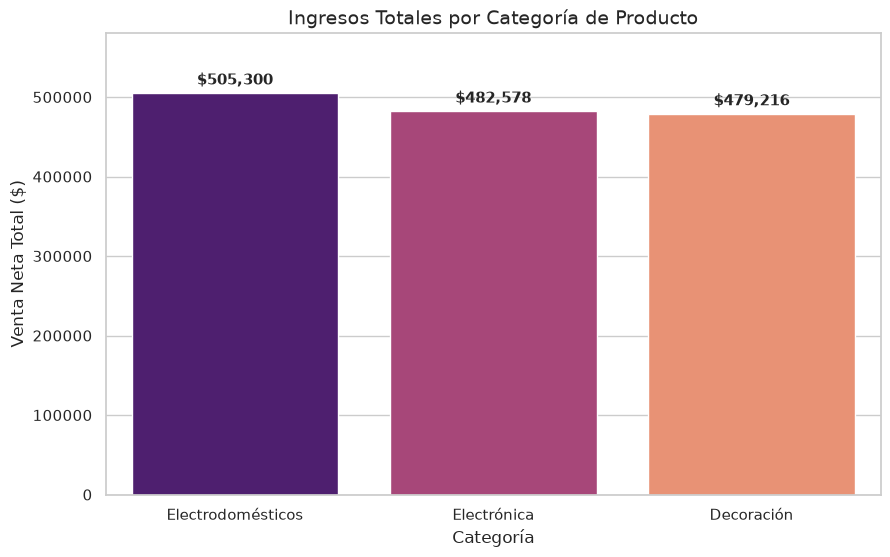

```python
import matplotlib.pyplot as plt
import seaborn as sns

# Configuración de estilo
sns.set_theme(style="whitegrid")
plt.figure(figsize=(10, 6))

# Crear gráfico de barras
ax = sns.barplot(
    data=resumen_categorias.reset_index().sort_values(by='ingresos_totales', ascending=False),
    x='categoria',
    y='ingresos_totales',
    palette='magma',
    hue='categoria',
    legend=False
)

# Añadir etiquetas de datos en las barras
for p in ax.patches:
    ax.annotate(f'${p.get_height():,.0f}',
                (p.get_x() + p.get_width() / 2., p.get_height()),
                ha='center', va='center',
                xytext=(0, 9),
                textcoords='offset points',
                fontsize=11,
                fontweight='bold')

plt.title('Ingresos Totales por Categoría de Producto', fontsize=14)
plt.xlabel('Categoría', fontsize=12)
plt.ylabel('Venta Neta Total ($)', fontsize=12)
plt.ylim(0, resumen_categorias['ingresos_totales'].max() * 1.15) # Espacio para las etiquetas

plt.show()
```

### 🏁 Cierre de Análisis y Branding

Visualización final con firma de autoría.

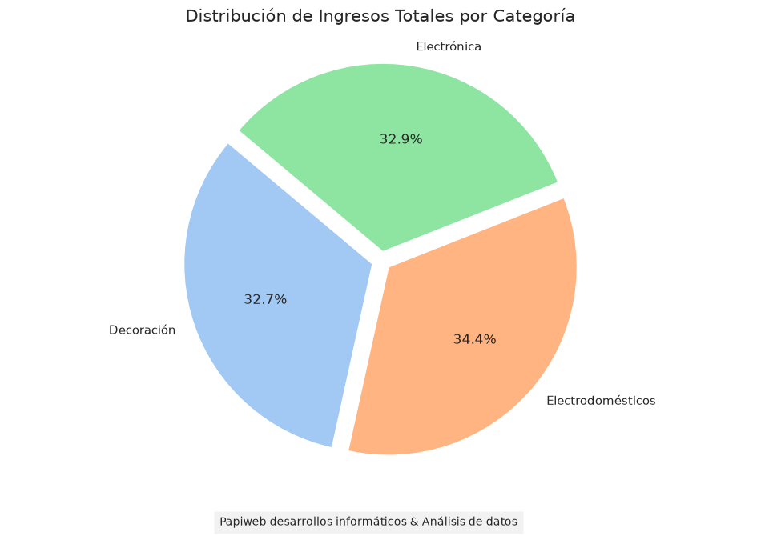

```python
import matplotlib.pyplot as plt
import seaborn as sns

# Configuramos el gráfico de rendimiento por categoría
plt.figure(figsize=(12, 7))
sns.set_theme(style="whitegrid")

# Gráfico de torta para ver la distribución porcentual
plt.pie(resumen_categorias['ingresos_totales'],
        labels=resumen_categorias.index,
        autopct='%1.1f%%',
        colors=sns.color_palette('pastel'),
        startangle=140,
        explode=(0.05, 0.05, 0.05))

plt.title('Distribución de Ingresos Totales por Categoría', fontsize=15, pad=20)

# Añadimos la marca de agua/pie de página solicitada
plt.figtext(0.5, 0.02, "Papiweb desarrollos informáticos & Análisis de datos",
            ha="center", fontsize=10, bbox=dict(facecolor='grey', alpha=0.1, pad=5))

plt.axis('equal')
plt.show()
```

### 💾 Guardado de Progreso Final

```python
# Exportamos a CSV en el directorio local
df_cli.to_csv('clientes_limpio.csv', index=False)
df_ven_pp.to_csv('ventas_procesado.csv', index=False)
df_mar_pp.to_csv('marketing_saneado.csv', index=False)
print("✅ Archivos guardados exitosamente en el directorio local.")
```

```
✅ Archivos guardados exitosamente en el directorio local.
```

# Papiweb Desarrollos Informáticos